# 6: Analysis of longitudinal data

Let’s also check for outliers with boxplots.

```r
RATSL_out <- data_RATSL %>%
  filter(Time > 0) %>%
  group_by(Group, ID) %>%
  summarise( mean=mean(Weight) ) %>%
  ungroup()
```

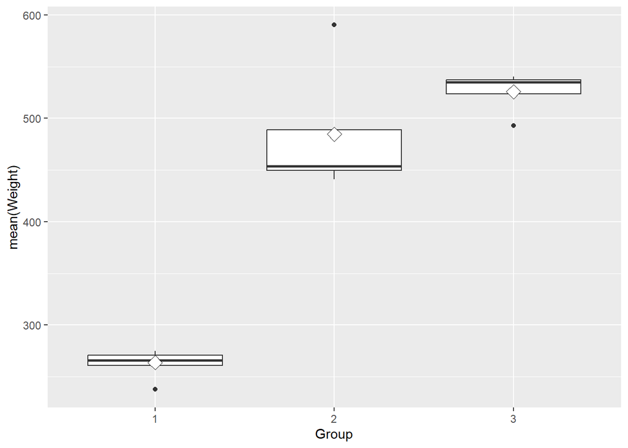

```r
ggplot(RATSL_out, aes(x = Group, y = mean)) +
  geom_boxplot() +
  stat_summary(fun = "mean", geom = "point", shape=23, size=4, fill = "white") +
  scale_y_continuous(name = "mean(Weight)")
```

It would seem like there is at least major outlier with group 2 that could be removed.

```r
RATSL_out1 <- RATSL_out %>%
  filter(mean < 570)
```

Let’s plot again.

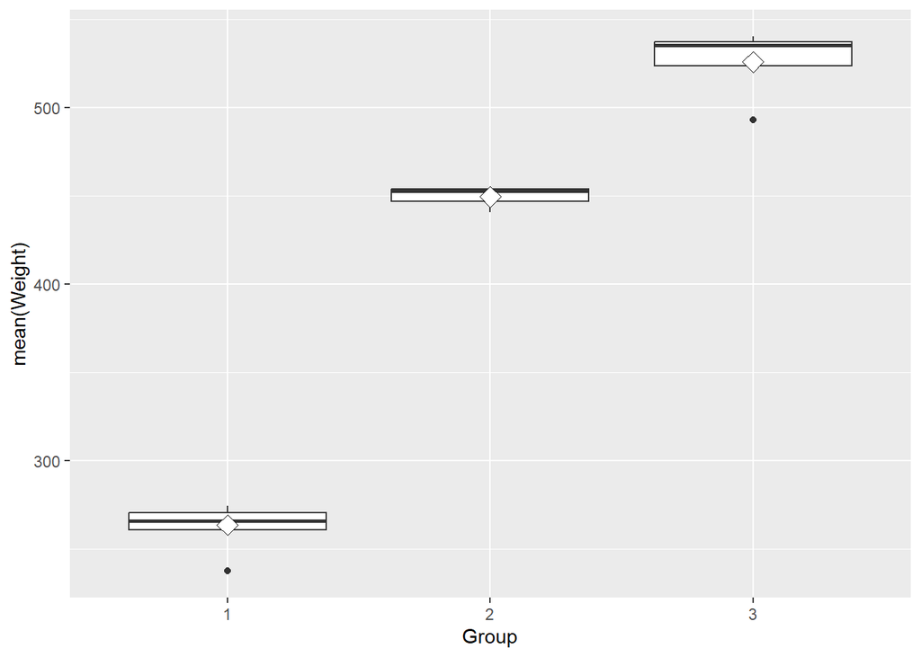

```r
ggplot(RATSL_out1, aes(x = Group, y = mean)) +
  geom_boxplot() +
  stat_summary(fun = "mean", geom = "point", shape=23, size=4, fill = "white") +
  scale_y_continuous(name = "mean(Weight)")
```

This had a major impact on the group 2. Its box became tighter and smaller. Maybe we can try this with group 1 also.

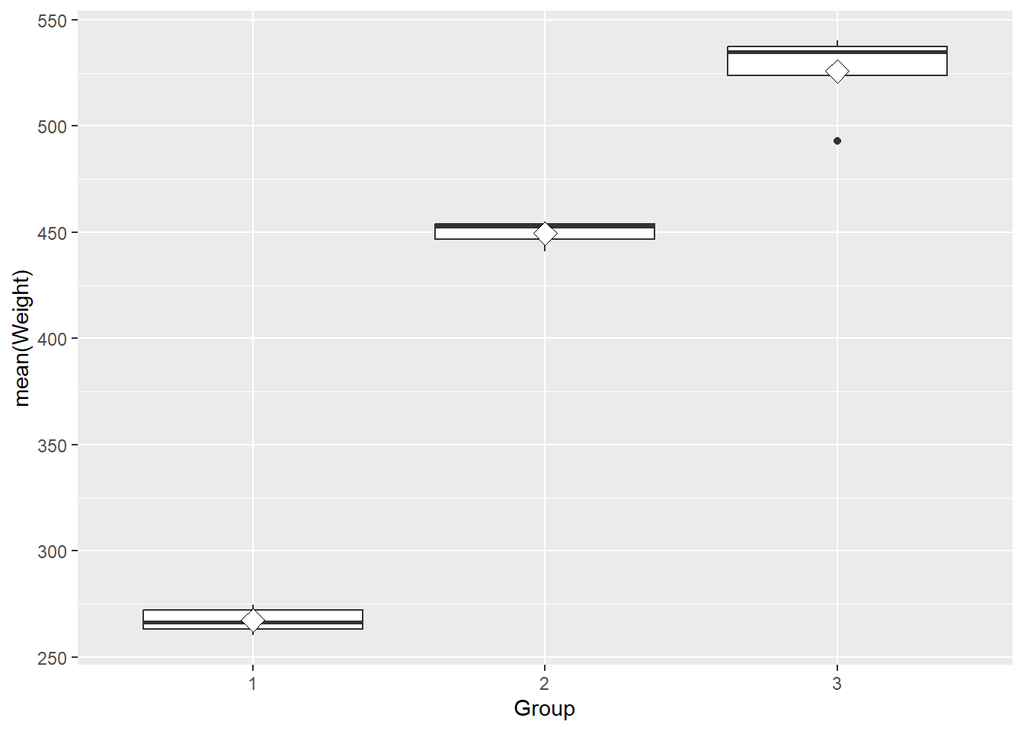

```r
RATSL_out2 <- RATSL_out1  %>%
  filter(mean > 240)

ggplot(RATSL_out2, aes(x = Group, y = mean)) +
  geom_boxplot() +
  stat_summary(fun = "mean", geom = "point", shape=23, size=4, fill = "white") +
  scale_y_continuous(name = "mean(Weight)")
```

With these test there might be a problems as there are only now only 3 rats in the group 2 as the outlier is removed. The effect of removing outlier is thus very big and impacts the results very much.

Then, let’s perform Anova to check for differences in groups. This needed some tweaking. I first read in the original RATS data set to get WD1 as its own column (following exercie set example). Then I have to remove rows that were removed earlier based on their low mean value. I identified the rows manually and removed them. This needed to be done so that mutate will work. It was otherwise giving error about different number of rows (14 vs 16). Then I can finally fit the model and conduct anova.

```r
#load in the original data
og_RATS <- read.table("https://raw.githubusercontent.com/KimmoVehkalahti/MABS/master/Examples/data/rats.txt", header = TRUE, sep = '\t')

#remove the rows (they are identified by hand)
data_RATSL_anova <- og_RATS[-c(2,12),]

RATSL_out2 <- RATSL_out2 %>%
  mutate(baseline = data_RATSL_anova$WD1)

# Fit the linear model with the mean as the response
rat_fit <- lm(mean ~baseline + Group, data = RATSL_out2)

#anova
anova(rat_fit)
```

```
## Analysis of Variance Table
##
## Response: mean
##           Df Sum Sq Mean Sq  F value    Pr(>F)
## baseline   1 188050  188050 3395.239 5.381e-14 ***
## Group      2   1362     681   12.291  0.002022 **
## Residuals 10    554      55
## ---
## Signif. codes:  0 '***' 0.001 '**' 0.01 '*' 0.05 '.' 0.1 ' ' 1
```

Baseline is highly significant. At least this tells us that the weights taken at baseline are highly relevant for the weights taken after the diet has begun. I did not find so much on what it actually tells us to use lm-model as an input for anova.

## BPRS

Let’s then apply Part II methods in Exercise6 to BPRS data. We have already transformed the data to long format. Let’s have a summary of it again.

```r
str(data_BPRSL)
```

```
## 'data.frame':    360 obs. of  5 variables:
##  $ treatment: int  1 1 1 1 1 1 1 1 1 1 ...
##  $ subject  : int  1 2 3 4 5 6 7 8 9 10 ...
##  $ weeks    : chr  "week0" "week0" "week0" "week0" ...
##  $ bprs     : int  42 58 54 55 72 48 71 30 41 57 ...
##  $ week     : int  0 0 0 0 0 0 0 0 0 0 ...
```

This data includes grouping based on which treatment subject was applied, subject-id, bprs-value and week-number. This data includes 40 respondents. BPRS means brief psychiatric rating scale (BPRS).

-data_BPRSL has now 360 rows and 5 columns. Separate week columns were transformed to a one weeks column -The week column was created by extracting the week number from the weeks column -Treatment variable tells about which treatment group study subjects belonged to. -Subject has subject number. There were 20 men in treatment 1- group and 20 to treatment 2. Hence the numbers -bprs is a value for “brief psychiatric rating scale (BPRS)” (quotes from the exercise texts) -“The BPRS assesses the level of 18 symptom constructs such as hostility, suspiciousness, hallucinations and grandiosity; each of these is rated from one (not present) to seven (extremely severe). -The scale is used to evaluate patients suspected of having schizophrenia.”

I am not sure why treatment and subhect are not factors even though I changed them. I will change them now again.

```r
data_BPRSL$treatment <- factor(data_BPRSL$treatment)
data_BPRSL$subject <- factor(data_BPRSL$subject)
str(data_BPRSL)
```

```
## 'data.frame':    360 obs. of  5 variables:
##  $ treatment: Factor w/ 2 levels "1","2": 1 1 1 1 1 1 1 1 1 1 ...
##  $ subject  : Factor w/ 20 levels "1","2","3","4",..: 1 2 3 4 5 6 7 8 9 10 ...
##  $ weeks    : chr  "week0" "week0" "week0" "week0" ...
##  $ bprs     : int  42 58 54 55 72 48 71 30 41 57 ...
##  $ week     : int  0 0 0 0 0 0 0 0 0 0 ...
```

Now they are factors.

Let’s then plot the data, following exercise. I use geom_smooth instead of geom_line as it produced weird plot. In the forums somebody had the same problem and recommended geom_smooth, because “it seemed to be about how ggplot connects the points in the graph, which if they are not evenly spaced can create that madness of graph. I went around this by changing the last”geom_line” for a “geom_smooth” and it worked quite well, but I am sure that Kimmo can explain further.”

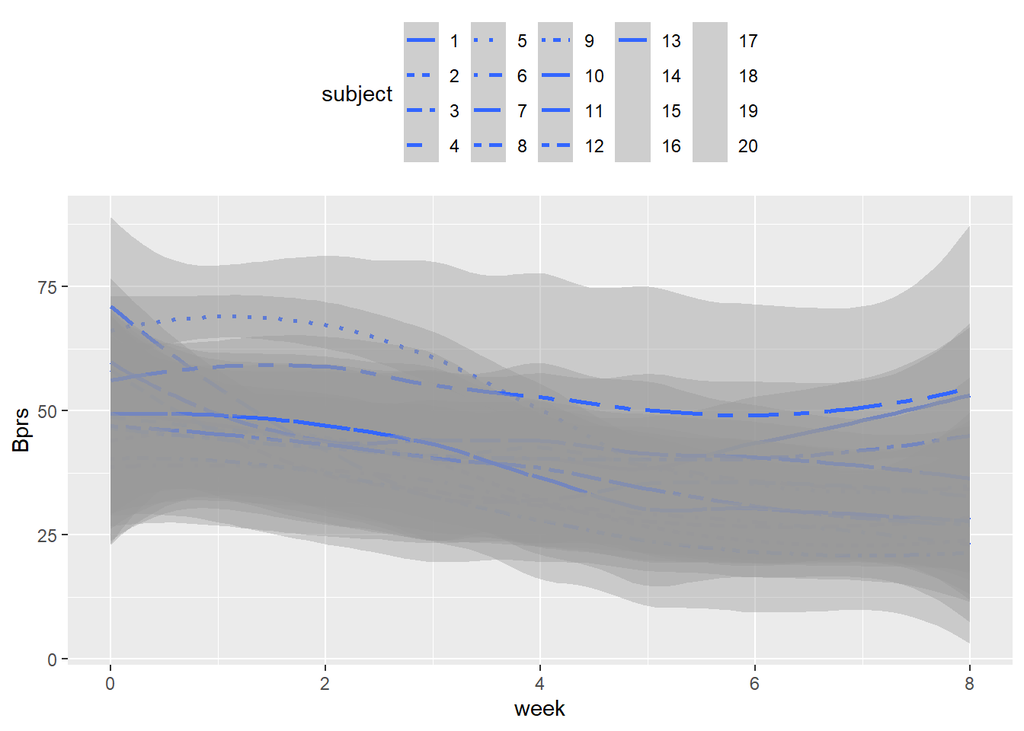

```r
ggplot(data_BPRSL, aes(x = week, y = bprs, group = subject)) +
  geom_smooth(aes(linetype = subject)) +
  scale_y_continuous(name = "Bprs") +
  theme(legend.position = "top")
```

I am not though sure what happens in this plot either. It seems that ggplot is running out of linetypes first of all as only 13 first subjects are drawn. These is also a lot of grey stuff which covers everything (apparently the confidence interval. Let’s try editing.

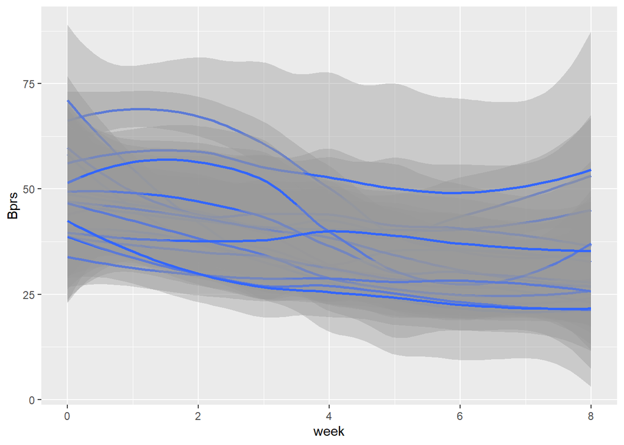

```r
ggplot(data_BPRSL, aes(x = week, y = bprs, group = subject)) +
  geom_smooth() +
  scale_y_continuous(name = "Bprs") +
  theme(legend.position = "top")
```

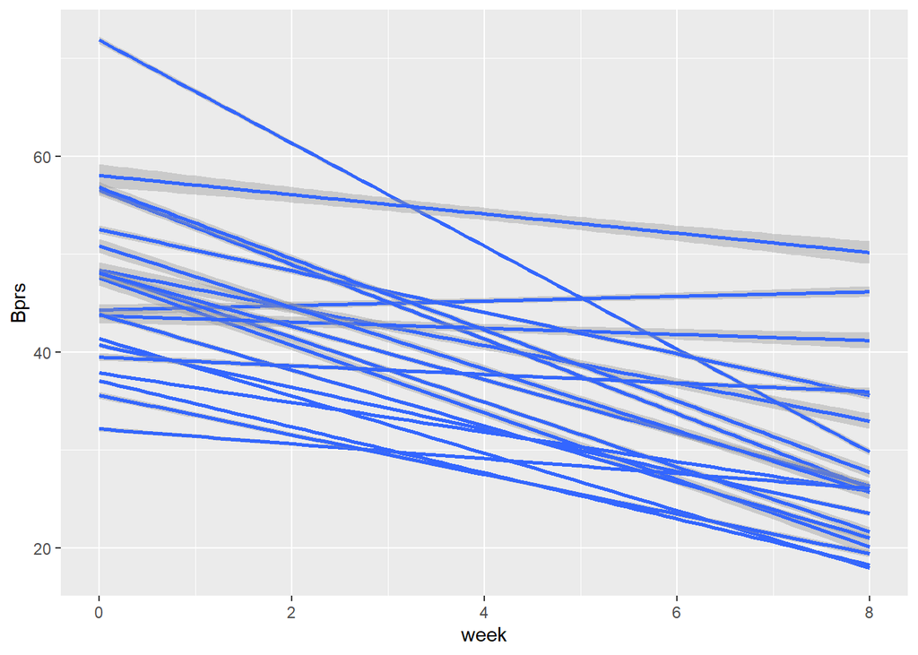

```r
ggplot(data_BPRSL, aes(x = week, y = bprs, group = subject)) +
  geom_smooth(method = "lm", level = 0.1) +
  scale_y_continuous(name = "Bprs") +
  theme(legend.position = "top")
```

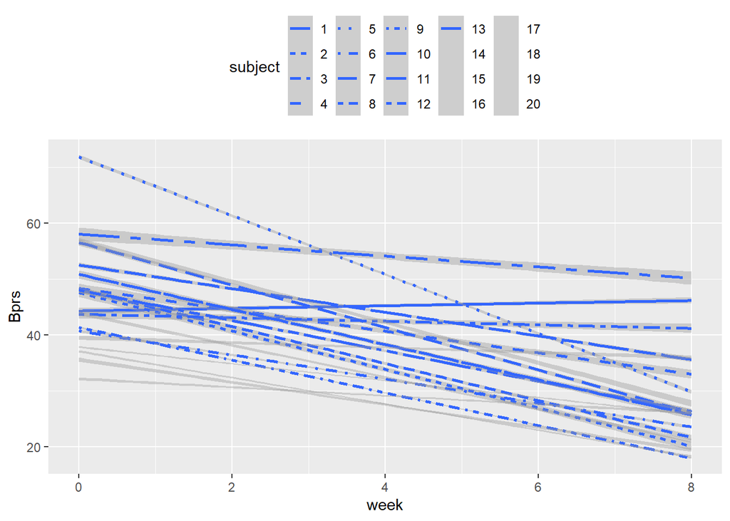

```r
ggplot(data_BPRSL, aes(x = week, y = bprs, group = subject)) +
  geom_smooth(method = "lm", level = 0.1, aes(linetype = subject)) +
  scale_y_continuous(name = "Bprs") +
  theme(legend.position = "top")
```

At least now some clarity was gotten and it is now easier to track the lines. Geom_smooth level-argument made the confidence level are smaller, and made this plot easier to analyze. We still miss rest of the linetypes but we can now at least see some trends (mostly downwards.) Some of the seem to be also increasing so it seems that not all respondents got any increasement in their mental well-being.

Let’s the conduct multiple linear regression, with bprs being target variable and week+treatment being explanatory variables. We are now ignoring the fact that there are now repeated measure on each individual which are very likely correlated (common problem with longitunal data).

```r
# create a regression model RATS_reg
BPRS_reg <- lm(bprs ~week+treatment, data = data_BPRSL)

# print out a summary of the model
summary(BPRS_reg)
```

```
##
## Call:
## lm(formula = bprs ~ week + treatment, data = data_BPRSL)
##
## Residuals:
##     Min      1Q  Median      3Q     Max
## -22.454  -8.965  -3.196   7.002  50.244
##
## Coefficients:
##             Estimate Std. Error t value Pr(>|t|)
## (Intercept)  46.4539     1.3670  33.982   <2e-16 ***
## week         -2.2704     0.2524  -8.995   <2e-16 ***
## treatment2    0.5722     1.3034   0.439    0.661
## ---
## Signif. codes:  0 '***' 0.001 '**' 0.01 '*' 0.05 '.' 0.1 ' ' 1
##
## Residual standard error: 12.37 on 357 degrees of freedom
## Multiple R-squared:  0.1851, Adjusted R-squared:  0.1806
## F-statistic: 40.55 on 2 and 357 DF,  p-value: < 2.2e-16
```

There is a negative slope with time passing and brps decreasing. This relatipnship is statistically significant. Treatment does not seem to have statistically significant relationship in this model.

Let’s then try The Random Intercept Model. This models is used to account for random effects in mixed-effects models. Random effect in our case come from the longitunal data. As we are taking same measurements from individuals, and try to then compare means of different groups of these individuals, the effect of these individuals and their “starting values” (in this case starting bprs) could have a huge effect on the results. Using mixed-effects model like The Random Intercept Model can be helpful to estimate the effect of those random effects. It provides more nuanced picture of the situation.

```r
BPRSR_ref <- lmer(bprs ~ week + treatment + (1 | subject), data = data_BPRSL, REML = FALSE)

# Print the summary of the model
summary(BPRSR_ref)
```

```
## Linear mixed model fit by maximum likelihood  ['lmerMod']
## Formula: bprs ~ week + treatment + (1 | subject)
##    Data: data_BPRSL
##
##      AIC      BIC   logLik deviance df.resid
##   2748.7   2768.1  -1369.4   2738.7      355
##
## Scaled residuals:
##     Min      1Q  Median      3Q     Max
## -3.0481 -0.6749 -0.1361  0.4813  3.4855
##
## Random effects:
##  Groups   Name        Variance Std.Dev.
##  subject  (Intercept)  47.41    6.885
##  Residual             104.21   10.208
## Number of obs: 360, groups:  subject, 20
##
## Fixed effects:
##             Estimate Std. Error t value
## (Intercept)  46.4539     1.9090  24.334
## week         -2.2704     0.2084 -10.896
## treatment2    0.5722     1.0761   0.532
##
## Correlation of Fixed Effects:
##            (Intr) week
## week       -0.437
## treatment2 -0.282  0.000
```

I am not the greatest at interpreting these results. First we have model fit values and residuals. The model fit values would be more meaningful when choosing best model. This well be dealt later.

Fixed results tell how week and treament affect brps. There is negative trend with week and small positive with treatment2.

Then there is the variance-covariance matrix of the random effects, which provides information about the variability of the random effects in the model. I am not sure if I should compare these values to the fixed effects. The variability seem to be quite big?

Let’s then try random intercept and random slope model. This model makes it possible also to account for individual slopes. This means that this model accounts not only different starting points but also different individual effects of treatments in our case.

```r
BPRSL_ref1 <- lmer(bprs ~ week + treatment + (week | subject), data = data_BPRSL, REML = FALSE)
summary(BPRSL_ref1)
```

```
## Linear mixed model fit by maximum likelihood  ['lmerMod']
## Formula: bprs ~ week + treatment + (week | subject)
##    Data: data_BPRSL
##
##      AIC      BIC   logLik deviance df.resid
##   2745.4   2772.6  -1365.7   2731.4      353
##
## Scaled residuals:
##     Min      1Q  Median      3Q     Max
## -2.8919 -0.6194 -0.0691  0.5531  3.7976
##
## Random effects:
##  Groups   Name        Variance Std.Dev. Corr
##  subject  (Intercept) 64.8222  8.0512
##           week         0.9609  0.9802   -0.51
##  Residual             97.4305  9.8707
## Number of obs: 360, groups:  subject, 20
##
## Fixed effects:
##             Estimate Std. Error t value
## (Intercept)  46.4539     2.1052  22.066
## week         -2.2704     0.2977  -7.626
## treatment2    0.5722     1.0405   0.550
##
## Correlation of Fixed Effects:
##            (Intr) week
## week       -0.582
## treatment2 -0.247  0.000
```

The model fit values are very similar to previous model. -Variance regarding “subject”-variable is higher -week is included in the random effects and has a smaller effect

Let’s perform ANOVA on these models.

```r
anova(BPRSL_ref1, BPRSR_ref)
```

```
## Data: data_BPRSL
## Models:
## BPRSR_ref: bprs ~ week + treatment + (1 | subject)
## BPRSL_ref1: bprs ~ week + treatment + (week | subject)
##            npar    AIC    BIC  logLik deviance  Chisq Df Pr(>Chisq)
## BPRSR_ref     5 2748.7 2768.1 -1369.4   2738.7
## BPRSL_ref1    7 2745.4 2772.6 -1365.7   2731.4 7.2721  2    0.02636 *
## ---
## Signif. codes:  0 '***' 0.001 '**' 0.01 '*' 0.05 '.' 0.1 ' ' 1
```

To my understanding, these models have very similar values. The difference seems to be that BPRSL_ref1 seems to have Chisq while the other don’t. It was mentioned in the exercise that “The lower the value the better the fit against the comparison model.” I don’t know how to compare the models based on that now.

```r
# create a random intercept and random slope model with the interaction
library(lme4)
BPRSL_ref2 <- lmer(bprs ~ week * treatment + (week | subject), data = data_BPRSL, REML = FALSE)
summary(BPRSL_ref2)
```

```
## Linear mixed model fit by maximum likelihood  ['lmerMod']
## Formula: bprs ~ week * treatment + (week | subject)
##    Data: data_BPRSL
##
##      AIC      BIC   logLik deviance df.resid
##   2744.3   2775.4  -1364.1   2728.3      352
##
## Scaled residuals:
##     Min      1Q  Median      3Q     Max
## -3.0512 -0.6271 -0.0768  0.5288  3.9260
##
## Random effects:
##  Groups   Name        Variance Std.Dev. Corr
##  subject  (Intercept) 64.9964  8.0620
##           week         0.9687  0.9842   -0.51
##  Residual             96.4707  9.8220
## Number of obs: 360, groups:  subject, 20
##
## Fixed effects:
##                 Estimate Std. Error t value
## (Intercept)      47.8856     2.2521  21.262
## week             -2.6283     0.3589  -7.323
## treatment2       -2.2911     1.9090  -1.200
## week:treatment2   0.7158     0.4010   1.785
##
## Correlation of Fixed Effects:
##             (Intr) week   trtmn2
## week        -0.650
## treatment2  -0.424  0.469
## wek:trtmnt2  0.356 -0.559 -0.840
```

```r
# perform an ANOVA test on the two models
anova(BPRSL_ref1, BPRSL_ref2)
```

```
## Data: data_BPRSL
## Models:
## BPRSL_ref1: bprs ~ week + treatment + (week | subject)
## BPRSL_ref2: bprs ~ week * treatment + (week | subject)
##            npar    AIC    BIC  logLik deviance  Chisq Df Pr(>Chisq)
## BPRSL_ref1    7 2745.4 2772.6 -1365.7   2731.4
## BPRSL_ref2    8 2744.3 2775.4 -1364.1   2728.3 3.1712  1    0.07495 .
## ---
## Signif. codes:  0 '***' 0.001 '**' 0.01 '*' 0.05 '.' 0.1 ' ' 1
```

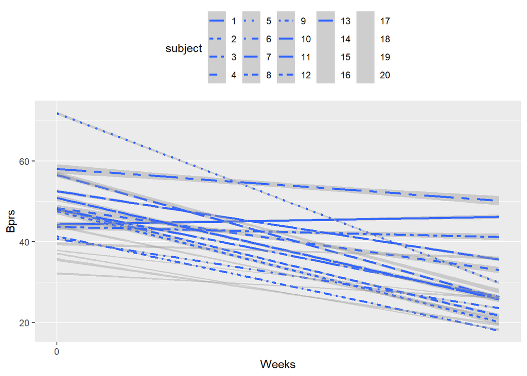

```r
# draw the plot of BPRS with the observed bprs values
ggplot(data_BPRSL, aes(x = week, y = bprs, group = subject)) +
  geom_smooth(method = "lm", level = 0.1, aes(linetype = subject)) +
  scale_x_continuous(name = "Weeks", breaks = seq(0, 1, 10)) +
  scale_y_continuous(name = "Bprs") +
  theme(legend.position = "top")
```

I don’t know how to choose between the models now as ANOVA test does not print chi-square value for both. But let’s choose the lates value then. This is not such a big problem (maybe) as these models seem to have very similar fit.

Let’s first create fitted-column having values created with the model.

```r
Fitted <- fitted(BPRSL_ref2)

data_BPRSL2 <- data_BPRSL %>%
  mutate(fitted = Fitted)
```

Let’s plot similar plot than before but with using the values from fitted model.

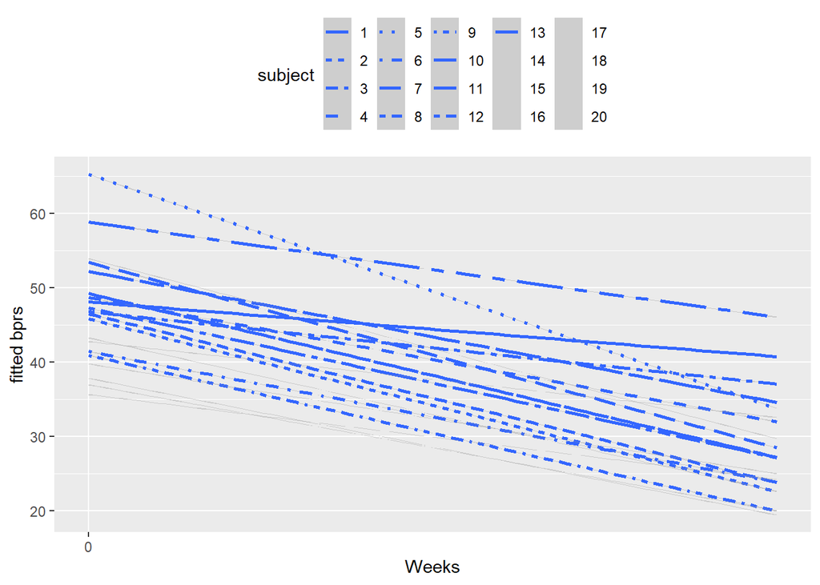

```r
ggplot(data_BPRSL2, aes(x = week, y = fitted, group = subject)) +
  geom_smooth(method = "lm", level = 0.1, aes(linetype = subject)) +
  scale_x_continuous(name = "Weeks", breaks = seq(0, 1, 10)) +
  scale_y_continuous(name = "fitted bprs") +
  theme(legend.position = "top")
```

These plots are quite similar but there are small differences. Some lines start from different positions and end up in different.